# Project 2: Investigate the European Soccer Database

- Introduction
- Data Wrangling
- Exploratory Data Analysis
- Conclusions

## Introduction

For this project, I will investigate the European Soccer Database from Kaggle which contains seven tables: "Country", "League", "Match", "Player", "Player_Attributes", "Team", and "Team_Attributes". This dataset covers 11 of the top European leagues from 2008 to 2016. As a lifelong football tragic, it was an easy choice to select this dataset for investigation.

The key questions that I would like to answer include:

1. **Home fortress?**: Does a home advantage exist, and if so, which league has the strongest such advantage?
2. **Who are the goal machines and goal leakers?**: Who are the best and worst performing home and away teams?
3. **Who runs North London?**: Which team in North London has achieved the most wins?
4. **Speedy gonzales**: Is pace a factor in a player's overall rating?

### Import Packages

```python
# Import packages

import pandas as pd
import numpy as np
import seaborn as sns
import matplotlib.pyplot as plt
%matplotlib inline
```

## Data Wrangling

### Data Gathering

To gather data, I downloaded the dataset as 'database.sqllite' from Kaggle. I also downloaded and installed 'TablePlus' (a SQL client) which I used to select and join datasets.

Firstly, I brainstormed what tables and fields I may require to answer my research questions.

I noted that I would primarily need:

1. the 'Match' table (joined with 'Country' and 'League' to distinguish between countries and leagues; and also joined with 'Team' to bring in team names), and
2. the 'Player' table (joined with 'Player_Attributes' to bring in the attribute-level data for players).

Then I used my knowledge of SQL to perform the required joins, and exported the data to csv format (see SQL scripts below).

**SQL script for (1): Exported as match.csv**

> SELECT Match.id,  
> Country.name AS country_name,  
> League.name AS league_name,  
> season,  
> stage,  
> date,  
> H.team_long_name AS home_team,  
> A.team_long_name AS away_team,  
> home_team_goal,  
> away_team_goal  
> FROM Match  
> JOIN Country on Country.id = Match.country_id  
> JOIN League on League.id = Match.league_id  
> LEFT JOIN Team AS H ON H.team_api_id = Match.home_team_api_id  
> LEFT JOIN Team AS A ON A.team_api_id = Match.away_team_api_id;

**SQL script for (2): Exported as player.csv**

> SELECT * FROM Player  
> INNER JOIN Player_Attributes ON Player.player_api_id = Player_Attributes.player_api_id;

### Import CSVs

```python
# Import CSVs

match = pd.read_csv('match.csv')
player = pd.read_csv('player.csv')
```

```python
# Explore 'match' data

match.head()
```

|  | id | country_name | league_name | season | stage | date | home_team | away_team | home_team_goal | away_team_goal |
| --- | --- | --- | --- | --- | --- | --- | --- | --- | --- | --- |
| 0 | 1 | Belgium | Belgium Jupiler League | 2008/2009 | 1 | 2008-08-17 00:00:00 | KRC Genk | Beerschot AC | 1 | 1 |
| 1 | 2 | Belgium | Belgium Jupiler League | 2008/2009 | 1 | 2008-08-16 00:00:00 | SV Zulte-Waregem | Sporting Lokeren | 0 | 0 |
| 2 | 3 | Belgium | Belgium Jupiler League | 2008/2009 | 1 | 2008-08-16 00:00:00 | KSV Cercle Brugge | RSC Anderlecht | 0 | 3 |
| 3 | 4 | Belgium | Belgium Jupiler League | 2008/2009 | 1 | 2008-08-17 00:00:00 | KAA Gent | RAEC Mons | 5 | 0 |
| 4 | 5 | Belgium | Belgium Jupiler League | 2008/2009 | 1 | 2008-08-16 00:00:00 | FCV Dender EH | Standard de Liège | 1 | 3 |

Ideas for data wrangling / feature engineering:

- Add a column indicating who the winner of the match was (i.e. home team, away team, or drawn).

```python
match.info()
```

```
<class 'pandas.core.frame.DataFrame'>
RangeIndex: 25979 entries, 0 to 25978
Data columns (total 10 columns):
 #   Column          Non-Null Count  Dtype
---  ------          --------------  -----
 0   id              25979 non-null  int64
 1   country_name    25979 non-null  object
 2   league_name     25979 non-null  object
 3   season          25979 non-null  object
 4   stage           25979 non-null  int64
 5   date            25979 non-null  object
 6   home_team       25979 non-null  object
 7   away_team       25979 non-null  object
 8   home_team_goal  25979 non-null  int64
 9   away_team_goal  25979 non-null  int64
dtypes: int64(4), object(6)
memory usage: 2.0+ MB
```

There do not seem to be any null values (25979 observations across all columns). Note, the need to drop null values has been avoided by selecting columns which do not have nulls during the data gathering phase (there are columns in the original SQL dataset which contain null values, and if these were carried into this dataset then I would have needed to drop the null values at that point).

Ideas for data wrangling / feature engineering:

- Date should be changed to date-time format.

```python
match.shape
```

```
(25979, 10)
```

```python
match.isnull().sum()
```

```
id                0
country_name      0
league_name       0
season            0
stage             0
date              0
home_team         0
away_team         0
home_team_goal    0
away_team_goal    0
dtype: int64
```

```python
match.duplicated().sum()
```

```
0
```

There do not seem to be any duplicated values.

```python
# Explore 'player' data

player.head()
```

|  | id | player_api_id | player_name | player_fifa_api_id | birthday | height | weight | id.1 | player_fifa_api_id.1 | player_api_id.1 | ... | vision | penalties | marking | standing_tackle | sliding_tackle | gk_diving | gk_handling | gk_kicking | gk_positioning | gk_reflexes |
| --- | --- | --- | --- | --- | --- | --- | --- | --- | --- | --- | --- | --- | --- | --- | --- | --- | --- | --- | --- | --- | --- |
| 0 | 1 | 505942 | Aaron Appindangoye | 218353 | 1992-02-29 00:00:00 | 182.88 | 187 | 1 | 218353 | 505942 | ... | 54.0 | 48.0 | 65.0 | 69.0 | 69.0 | 6.0 | 11.0 | 10.0 | 8.0 | 8.0 |
| 1 | 1 | 505942 | Aaron Appindangoye | 218353 | 1992-02-29 00:00:00 | 182.88 | 187 | 2 | 218353 | 505942 | ... | 54.0 | 48.0 | 65.0 | 69.0 | 69.0 | 6.0 | 11.0 | 10.0 | 8.0 | 8.0 |
| 2 | 1 | 505942 | Aaron Appindangoye | 218353 | 1992-02-29 00:00:00 | 182.88 | 187 | 3 | 218353 | 505942 | ... | 54.0 | 48.0 | 65.0 | 66.0 | 69.0 | 6.0 | 11.0 | 10.0 | 8.0 | 8.0 |
| 3 | 1 | 505942 | Aaron Appindangoye | 218353 | 1992-02-29 00:00:00 | 182.88 | 187 | 4 | 218353 | 505942 | ... | 53.0 | 47.0 | 62.0 | 63.0 | 66.0 | 5.0 | 10.0 | 9.0 | 7.0 | 7.0 |
| 4 | 1 | 505942 | Aaron Appindangoye | 218353 | 1992-02-29 00:00:00 | 182.88 | 187 | 5 | 218353 | 505942 | ... | 53.0 | 47.0 | 62.0 | 63.0 | 66.0 | 5.0 | 10.0 | 9.0 | 7.0 | 7.0 |

5 rows × 49 columns

```python
player.info()
```

```
<class 'pandas.core.frame.DataFrame'>
RangeIndex: 183978 entries, 0 to 183977
Data columns (total 49 columns):
 #   Column                Non-Null Count   Dtype
---  ------                --------------   -----
 0   id                    183978 non-null  int64
 1   player_api_id         183978 non-null  int64
 2   player_name           183978 non-null  object
 3   player_fifa_api_id    183978 non-null  int64
 4   birthday              183978 non-null  object
 5   height                183978 non-null  float64
 6   weight                183978 non-null  int64
 7   id.1                  183978 non-null  int64
 8   player_fifa_api_id.1  183978 non-null  int64
 9   player_api_id.1       183978 non-null  int64
```

[output cut: 41 more lines]

I do not intend to use 'date', so I will not clean this. There are evidently null values throughout the dataset which I will dig into further.

```python
player.shape
```

```
(183978, 49)
```

```python
player.isnull().sum()
```

```
id                         0
player_api_id              0
player_name                0
player_fifa_api_id         0
birthday                   0
height                     0
weight                     0
id.1                       0
player_fifa_api_id.1       0
player_api_id.1            0
date                       0
overall_rating           836
potential                836
preferred_foot           836
attacking_work_rate     3230
defensive_work_rate      836
crossing                 836
finishing                836
heading_accuracy         836
short_passing            836
volleys                 2713
dribbling                836
curve                   2713
free_kick_accuracy       836
long_passing             836
ball_control             836
acceleration             836
sprint_speed             836
agility                 2713
reactions                836
balance                 2713
shot_power               836
jumping                 2713
stamina                  836
strength                 836
long_shots               836
aggression               836
interceptions            836
positioning              836
vision                  2713
penalties                836
marking                  836
standing_tackle          836
sliding_tackle          2713
gk_diving                836
gk_handling              836
gk_kicking               836
gk_positioning           836
gk_reflexes              836
dtype: int64
```

From a total of 183978 rows, there are a number of columns which contain between 836 and 3230 rows of null values. Given the research question which relies on the 'player' dataset is more concerned at a broader / macro level trend, I have taken the decision to drop all null values.

```python
player.duplicated().sum()
```

```
0
```

### Data Cleaning

```python
# Clean 'match' data

match_clean = match.copy()
```

```python
# Convert 'date' to datetime format

match_clean['date'] = match_clean['date'].astype('datetime64[ns]')
```

```python
match_clean.info()
```

```
<class 'pandas.core.frame.DataFrame'>
RangeIndex: 25979 entries, 0 to 25978
Data columns (total 10 columns):
 #   Column          Non-Null Count  Dtype
---  ------          --------------  -----
 0   id              25979 non-null  int64
 1   country_name    25979 non-null  object
 2   league_name     25979 non-null  object
 3   season          25979 non-null  object
 4   stage           25979 non-null  int64
 5   date            25979 non-null  datetime64[ns]
 6   home_team       25979 non-null  object
 7   away_team       25979 non-null  object
 8   home_team_goal  25979 non-null  int64
 9   away_team_goal  25979 non-null  int64
dtypes: datetime64[ns](1), int64(4), object(5)
memory usage: 2.0+ MB
```

```python
# Clean 'player' data

player_clean = player.copy()
```

```python
# Drop null values

player_clean.dropna(inplace=True)
```

```python
player_clean.isnull().sum()
```

```
id                      0
player_api_id           0
player_name             0
player_fifa_api_id      0
birthday                0
height                  0
weight                  0
id.1                    0
player_fifa_api_id.1    0
player_api_id.1         0
date                    0
overall_rating          0
potential               0
preferred_foot          0
attacking_work_rate     0
defensive_work_rate     0
crossing                0
finishing               0
heading_accuracy        0
short_passing           0
volleys                 0
dribbling               0
curve                   0
free_kick_accuracy      0
long_passing            0
ball_control            0
acceleration            0
sprint_speed            0
agility                 0
reactions               0
balance                 0
shot_power              0
jumping                 0
stamina                 0
strength                0
long_shots              0
aggression              0
interceptions           0
positioning             0
vision                  0
penalties               0
marking                 0
standing_tackle         0
sliding_tackle          0
gk_diving               0
gk_handling             0
gk_kicking              0
gk_positioning          0
gk_reflexes             0
dtype: int64
```

### Feature Engineering

```python
match_clean.head()
```

|  | id | country_name | league_name | season | stage | date | home_team | away_team | home_team_goal | away_team_goal |
| --- | --- | --- | --- | --- | --- | --- | --- | --- | --- | --- |
| 0 | 1 | Belgium | Belgium Jupiler League | 2008/2009 | 1 | 2008-08-17 | KRC Genk | Beerschot AC | 1 | 1 |
| 1 | 2 | Belgium | Belgium Jupiler League | 2008/2009 | 1 | 2008-08-16 | SV Zulte-Waregem | Sporting Lokeren | 0 | 0 |
| 2 | 3 | Belgium | Belgium Jupiler League | 2008/2009 | 1 | 2008-08-16 | KSV Cercle Brugge | RSC Anderlecht | 0 | 3 |
| 3 | 4 | Belgium | Belgium Jupiler League | 2008/2009 | 1 | 2008-08-17 | KAA Gent | RAEC Mons | 5 | 0 |
| 4 | 5 | Belgium | Belgium Jupiler League | 2008/2009 | 1 | 2008-08-16 | FCV Dender EH | Standard de Liège | 1 | 3 |

```python
# Create function to determine outcome of the match, and then create a column that contains this information

def outcome(a):
    home_score = a[0]
    away_score = a[1]
    home_team = a[2]
    away_team = a[3]

    if home_score > away_score:
        return home_team
    elif home_score < away_score:
        return away_team
    else:
        return 'Drawn'

match_clean['outcome']  = match_clean[['home_team_goal', 'away_team_goal', 'home_team', 'away_team']].apply(outcome, axis=1)
```

Note, I used the following GitHub repo as a guide for the above function: https://github.com/ozlerhakan/soccer/blob/master/investigate-a-dataset-template-main.ipynb

```python
match_clean.head()
```

|  | id | country_name | league_name | season | stage | date | home_team | away_team | home_team_goal | away_team_goal | outcome |
| --- | --- | --- | --- | --- | --- | --- | --- | --- | --- | --- | --- |
| 0 | 1 | Belgium | Belgium Jupiler League | 2008/2009 | 1 | 2008-08-17 | KRC Genk | Beerschot AC | 1 | 1 | Drawn |
| 1 | 2 | Belgium | Belgium Jupiler League | 2008/2009 | 1 | 2008-08-16 | SV Zulte-Waregem | Sporting Lokeren | 0 | 0 | Drawn |
| 2 | 3 | Belgium | Belgium Jupiler League | 2008/2009 | 1 | 2008-08-16 | KSV Cercle Brugge | RSC Anderlecht | 0 | 3 | RSC Anderlecht |
| 3 | 4 | Belgium | Belgium Jupiler League | 2008/2009 | 1 | 2008-08-17 | KAA Gent | RAEC Mons | 5 | 0 | KAA Gent |
| 4 | 5 | Belgium | Belgium Jupiler League | 2008/2009 | 1 | 2008-08-16 | FCV Dender EH | Standard de Liège | 1 | 3 | Standard de Liège |

## Exploratory Data Analysis

### Research Question 1)

**Home fortress?**: Does a home advantage exist, and if so, which league has the strongest such advantage?

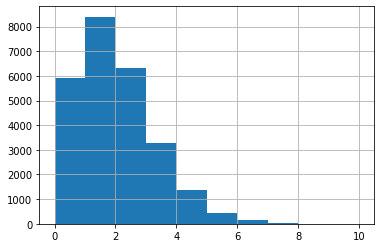

```python
# Distribution of home team goals across all leagues

match_clean.home_team_goal.hist();
```

```python
match_clean.home_team_goal.describe()
```

```
count    25979.000000
mean         1.544594
std          1.297158
min          0.000000
25%          1.000000
50%          1.000000
75%          2.000000
max         10.000000
Name: home_team_goal, dtype: float64
```

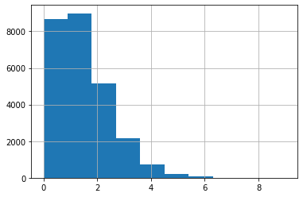

```python
# Distribution of away team goals across all leagues

match_clean.away_team_goal.hist();
```

```python
match_clean.away_team_goal.describe()
```

```
count    25979.000000
mean         1.160938
std          1.142110
min          0.000000
25%          0.000000
50%          1.000000
75%          2.000000
max          9.000000
Name: away_team_goal, dtype: float64
```

The initial histograms and summary statistics indicate that, on average, the home team scores 1.54 goals per game whilst the away team scores 1.16 goals per game, across the major European leagues. This indicates that there is some kind of home advantage.

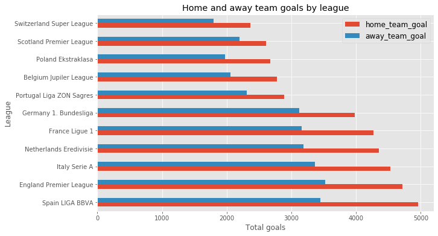

```python
# Plot of home and away team goals by league

goals = match_clean.groupby('league_name').agg({"home_team_goal":"sum","away_team_goal":"sum"}).sort_values(['home_team_goal'],ascending=False)
goals.plot(kind="barh", figsize = (10,6))
plt.title("Home and away team goals by league")
plt.style.use('ggplot') # playing around with styles
plt.legend(loc = "best" , prop = {"size" : 12})
plt.xlabel("Total goals")
plt.ylabel("League")
plt.show();
```

This plot shows that the home advantage exists across each league (to varying degrees).

The plot also shows that the top three leagues with highest home (and away goals) scored are:

- Spain LIGA BBVA
- England Premier League
- Italy Serie A

```python
# Plot home goals only

home_league_goals = match_clean.groupby('league_name')[['home_team_goal']].sum().sum(axis=1).sort_values(ascending=False)
home_league_goals
```

```
league_name
Spain LIGA BBVA             4959
England Premier League      4715
Italy Serie A               4528
Netherlands Eredivisie      4357
France Ligue 1              4265
Germany 1. Bundesliga       3982
Portugal Liga ZON Sagres    2890
Belgium Jupiler League      2781
Poland Ekstraklasa          2678
Scotland Premier League     2607
Switzerland Super League    2365
dtype: int64
```

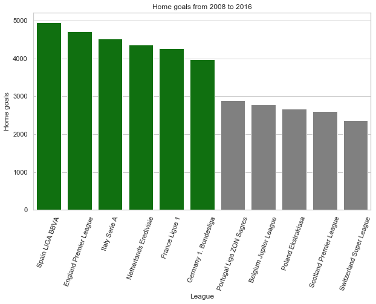

```python
# Using Seaborn to plot the results

sns.set(style="whitegrid")
h_labels = home_league_goals.index
h_values = home_league_goals
h_mean = h_values.mean()
colours = ['grey' if (x < h_mean) else 'green' for x in h_values] # Green shading for above average results
plt.figure(figsize=(10,6))
sns.barplot(x=h_labels,y=h_values, palette=colours)
plt.title('Home goals from 2008 to 2016')
plt.xticks(rotation=70)
plt.xlabel('League')
plt.ylabel('Home goals');
```

Here we can see a stark difference between two subgroups across the 11 leagues (green shade are above average, and grey shade are below average). This makes me wonder whether there are an even amount of matches played across all leagues.

```python
# Plot away goals only

away_league_goals = match_clean.groupby('league_name')[['away_team_goal']].sum().sum(axis=1).sort_values(ascending=False)
away_league_goals
```

```
league_name
England Premier League      3525
Spain LIGA BBVA             3453
Italy Serie A               3367
Netherlands Eredivisie      3185
France Ligue 1              3162
Germany 1. Bundesliga       3121
Portugal Liga ZON Sagres    2311
Scotland Premier League     2197
Belgium Jupiler League      2060
Poland Ekstraklasa          1978
Switzerland Super League    1801
dtype: int64
```

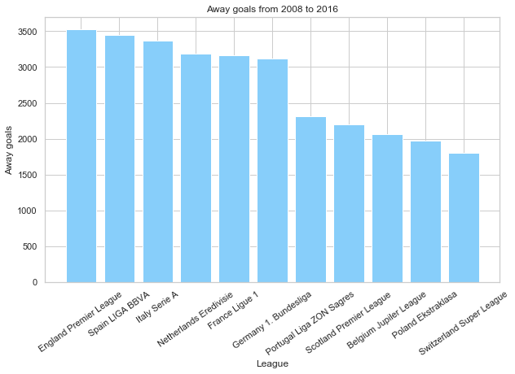

```python
# Using matplotlib to plot the results

sns.set(style="whitegrid")
a_labels = away_league_goals.index
a_values = away_league_goals
a_mean = a_values.mean()
plt.figure(figsize=(10,6))
plt.bar(x=a_labels,height=a_values, color='lightskyblue')
plt.title('Away goals from 2008 to 2016')
plt.xticks(rotation=35)
plt.xlabel('League')
plt.ylabel('Away goals');
```

We can see a similar pattern emerging for away goals. Here I decided to use a plt bar plot.

```python
# Find the number of matches played per league

matches_played = match_clean.groupby('league_name')
matches_played.id.count().sort_values(ascending=False)
```

```
league_name
Spain LIGA BBVA             3040
France Ligue 1              3040
England Premier League      3040
Italy Serie A               3017
Netherlands Eredivisie      2448
Germany 1. Bundesliga       2448
Portugal Liga ZON Sagres    2052
Poland Ekstraklasa          1920
Scotland Premier League     1824
Belgium Jupiler League      1728
Switzerland Super League    1422
Name: id, dtype: int64
```

To determine whether the previous plot provides a true indication of which leagues have the highest goals scored, I decided to check whether the number of matches played was the same across the leagues.

As per the above output, there is a significant difference across the leagues in terms of total matches played. This would make the previous plot of just relying on total goals misleading if seeking to compare goals scored across leagues.

```python
# Calculate mean goals scored per match per league

mean_goals = match_clean[['league_name','home_team_goal','away_team_goal']].groupby('league_name').mean().sort_values('home_team_goal', ascending=False)
```

```python
mean_goals
```

| league_name | home_team_goal | away_team_goal |
| --- | --- | --- |
| Netherlands Eredivisie | 1.779820 | 1.301062 |
| Switzerland Super League | 1.663150 | 1.266526 |
| Spain LIGA BBVA | 1.631250 | 1.135855 |
| Germany 1. Bundesliga | 1.626634 | 1.274918 |
| Belgium Jupiler League | 1.609375 | 1.192130 |
| England Premier League | 1.550987 | 1.159539 |
| Italy Serie A | 1.500829 | 1.116009 |
| Scotland Premier League | 1.429276 | 1.204496 |
| Portugal Liga ZON Sagres | 1.408382 | 1.126218 |
| France Ligue 1 | 1.402961 | 1.040132 |
| Poland Ekstraklasa | 1.394792 | 1.030208 |

By calculating mean goals scored per game, we see a different story emerging. If we focus on home team goals, the top three leagues are now:

- Netherlands Eredivisie
- Switzerland Super League
- Spain LIGA BBVA

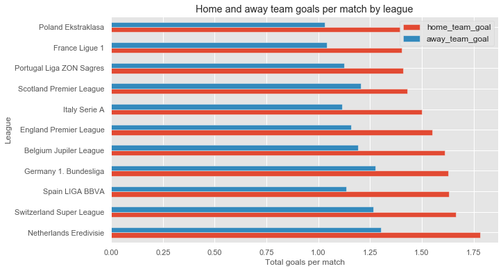

```python
# Plot of home and away team goals by league

mean_goals.plot(kind="barh", figsize = (10,6))
plt.title("Home and away team goals per match by league")
plt.style.use('ggplot')
plt.legend(loc = "best" , prop = {"size" : 12})
plt.xlabel("Total goals per match")
plt.ylabel("League");
```

```python
# Calculate ratio of home to away goals per league to get a % breakdown

mean_total_goals = mean_goals['home_team_goal'] + mean_goals['away_team_goal']

mean_goals['home_team_goal_percent'] = 100 * mean_goals['home_team_goal'] / mean_total_goals
mean_goals['away_team_goal_percent'] = 100 * mean_goals['away_team_goal'] / mean_total_goals

mean_goals_percent = mean_goals[['home_team_goal_percent','away_team_goal_percent']].sort_values('home_team_goal_percent', ascending=False)
```

```python
mean_goals_percent
```

| league_name | home_team_goal_percent | away_team_goal_percent |
| --- | --- | --- |
| Spain LIGA BBVA | 58.951498 | 41.048502 |
| Netherlands Eredivisie | 57.769822 | 42.230178 |
| Poland Ekstraklasa | 57.517182 | 42.482818 |
| Belgium Jupiler League | 57.446809 | 42.553191 |
| France Ligue 1 | 57.425609 | 42.574391 |
| Italy Serie A | 57.352755 | 42.647245 |
| England Premier League | 57.220874 | 42.779126 |
| Switzerland Super League | 56.769083 | 43.230917 |
| Germany 1. Bundesliga | 56.060819 | 43.939181 |
| Portugal Liga ZON Sagres | 55.566237 | 44.433763 |
| Scotland Premier League | 54.267277 | 45.732723 |